# Practice Activity 6.2

Import the Palmer Penguins dataset and print out the first few rows.

Suppose we want to predict `bill_depth_mm` using the other variables in the dataset.

**Dummify** all variables that require this.

```python
#!pip install palmerpenguins
```

```python
import pandas as pd
import numpy as np
from palmerpenguins import load_penguins
from plotnine import ggplot, geom_point, aes, geom_line
from sklearn.linear_model import LinearRegression
from sklearn.pipeline import Pipeline
from sklearn.metrics import r2_score
from sklearn.metrics import mean_absolute_error, r2_score, mean_squared_error
from sklearn.model_selection import train_test_split
import random
```

```python
# Code Here
df = load_penguins()
df.head()
```

|  | species | island | bill_length_mm | bill_depth_mm | flipper_length_mm | body_mass_g | sex | year |
| --- | --- | --- | --- | --- | --- | --- | --- | --- |
| 0 | Adelie | Torgersen | 39.1 | 18.7 | 181.0 | 3750.0 | male | 2007 |
| 1 | Adelie | Torgersen | 39.5 | 17.4 | 186.0 | 3800.0 | female | 2007 |
| 2 | Adelie | Torgersen | 40.3 | 18.0 | 195.0 | 3250.0 | female | 2007 |
| 3 | Adelie | Torgersen | NaN | NaN | NaN | NaN | NaN | 2007 |
| 4 | Adelie | Torgersen | 36.7 | 19.3 | 193.0 | 3450.0 | female | 2007 |

```python
df = pd.get_dummies(df, columns=['species', 'island', 'sex'], drop_first=True)
df = df.dropna()
cols = ['species_Chinstrap','species_Gentoo', 'island_Dream', 'island_Torgersen', 'sex_male']
df[cols] = df[cols].astype(int)



df.head()
df.columns
```

```
Index(['bill_length_mm', 'bill_depth_mm', 'flipper_length_mm', 'body_mass_g',
       'year', 'species_Chinstrap', 'species_Gentoo', 'island_Dream',
       'island_Torgersen', 'sex_male'],
      dtype='object')
```

Let’s use the other variables to predict `bill_depth_mm`. Prepare your data and fit the following models on a training dataset subset of the entire dataset:

- Four different models, each containing a different set of predictor variables

Create a plot like the right plot of Fig 1. in our `Model Validation` chapter with the training and test error plotted for each of your four models.

Which of your models was best?

```python
# Code Here
total = list(df.columns)
models = {
  "Model 1": ["flipper_length_mm"],
  "Model 2": ["flipper_length_mm","body_mass_g"],
  "Model 3": ["flipper_length_mm","body_mass_g","sex_male"],
  "Model 4": ["flipper_length_mm","body_mass_g","sex_male","species_Chinstrap","island_Torgersen"],
}

y = df["bill_depth_mm"]

X = df[models["Model 4"]]
X_train, X_test, y_train, y_test = train_test_split(X, y, test_size=0.2)


train_rows = []

for name, Xcols in models.items():
    X_train_sub = X_train[Xcols]

    model = LinearRegression().fit(X_train_sub, y_train)
    y_train_pred = model.predict(X_train_sub)

    train_mse = mean_squared_error(y_train, y_train_pred)
    train_rmse = np.sqrt(train_mse)
    train_r2 = r2_score(y_train, y_train_pred)

    train_rows.append({
        "Model": name,
        "Train RMSE": train_rmse,
        "Train R2": train_r2
    })

train_error = pd.DataFrame(train_rows)
train_error
```

|  | Model | Train RMSE | Train R2 |
| --- | --- | --- | --- |
| 0 | Model 1 | 1.564222 | 0.346061 |
| 1 | Model 2 | 1.554867 | 0.353860 |
| 2 | Model 3 | 1.144231 | 0.650081 |
| 3 | Model 4 | 1.086996 | 0.684211 |

```python
test_rows = []

for name, Xcols in models.items():
    X_train_sub = X_train[Xcols]
    X_test_sub = X_test[Xcols]

    model = LinearRegression().fit(X_train_sub, y_train)
    y_test_pred = model.predict(X_test_sub)

    test_rmse = np.sqrt(mean_squared_error(y_test, y_test_pred))
    test_r2 = r2_score(y_test, y_test_pred)

    test_rows.append({
        "Model": name,
        "Test RMSE": test_rmse,
        "Test R2": test_r2
    })

test_error = pd.DataFrame(test_rows)
test_error
```

|  | Model | Test RMSE | Test R2 |
| --- | --- | --- | --- |
| 0 | Model 1 | 1.754152 | 0.249592 |
| 1 | Model 2 | 1.755066 | 0.248810 |
| 2 | Model 3 | 1.252086 | 0.617676 |
| 3 | Model 4 | 1.173872 | 0.663950 |

```python
df_error = train_error.merge(test_error, on="Model")
df_error
```

|  | Model | Train RMSE | Train R2 | Test RMSE | Test R2 |
| --- | --- | --- | --- | --- | --- |
| 0 | Model 1 | 1.564222 | 0.346061 | 1.754152 | 0.249592 |
| 1 | Model 2 | 1.554867 | 0.353860 | 1.755066 | 0.248810 |
| 2 | Model 3 | 1.144231 | 0.650081 | 1.252086 | 0.617676 |
| 3 | Model 4 | 1.086996 | 0.684211 | 1.173872 | 0.663950 |

```python
df_error_long = df_error[["Model", "Train RMSE", "Test RMSE"]].melt(id_vars=["Model"], value_name = "RMSE", var_name = "type")
df_error_long
```

|  | Model | type | RMSE |
| --- | --- | --- | --- |
| 0 | Model 1 | Train RMSE | 1.564222 |
| 1 | Model 2 | Train RMSE | 1.554867 |
| 2 | Model 3 | Train RMSE | 1.144231 |
| 3 | Model 4 | Train RMSE | 1.086996 |
| 4 | Model 1 | Test RMSE | 1.754152 |
| 5 | Model 2 | Test RMSE | 1.755066 |
| 6 | Model 3 | Test RMSE | 1.252086 |
| 7 | Model 4 | Test RMSE | 1.173872 |

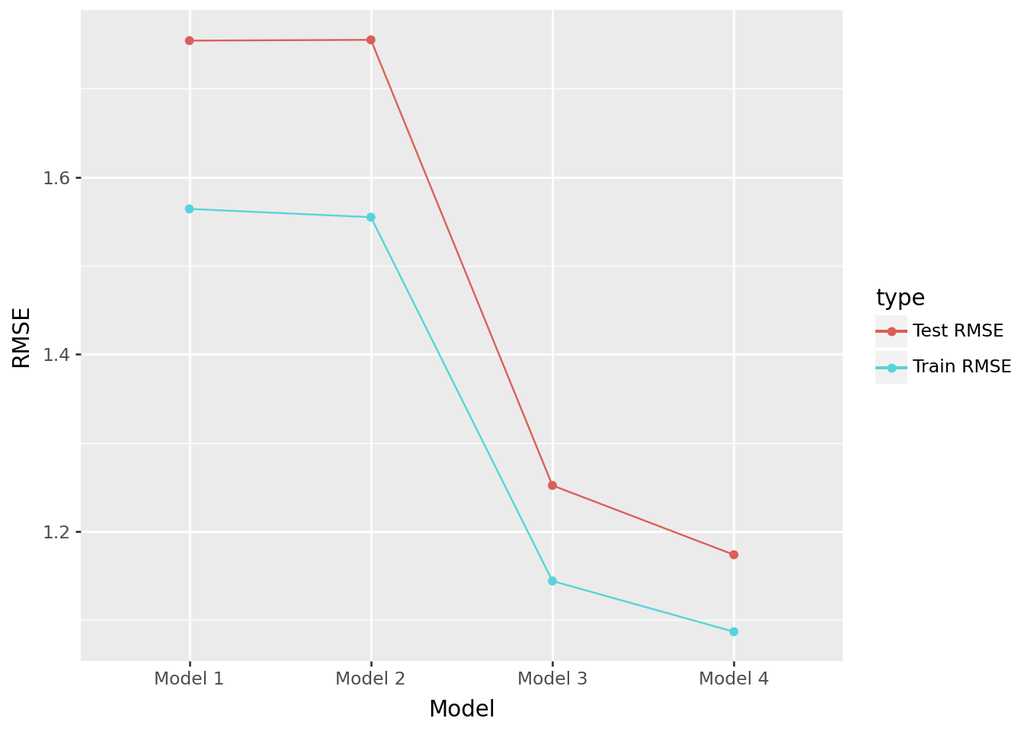

```python
(ggplot(df_error_long,
        aes(x = "Model",
            y = "RMSE",
            color = "type",
            group = "type"))
 +geom_line()
 +geom_point()

 )
```